# Analysis of OTM2

Frederik Aust

05 März, 2025

```r
# Default ggplot theme
theme_set(theme_apa())

# Number of MCMC samples for Bayesian analysis
tar_load(otm2_n_mcmc_samples)
```

```r
tar_load(otm2_attitudes)
tar_load(otm2_attitudes_collapsed)
otm2_iat <- tar_read(otm2_iat2)
otm2_mem <- tar_read(otm2_memory)
tar_load(otm2_log)
```

In Experiment 2, we aimed to replicate the results of Experiment 1 with a shorter presentation duration. Or pilot testing indicated that we would have to present the briefly flashed primes during the learning phase for 13 ms to achieve at-chance recognition accuracy. During peer review reviewers prompted us to add an additional condition of 20 ms to ensure that our presentation duration long enough to process the primes.

The results of Experiment 2 fully confirm the results of Experiment 1. Prime recognition accuracy was at chance level for the 13 ms condition and slightly above chance for the 20 ms condition. We found the same pattern of results for explicit ratings and IAT scores regardless of the presentation duration.

The following is an overview of the frequentist analysis of the data. The Bayesian replication analysis is currently under way and will be reported in the draft for the Stage 2-submission.

# 1 Participants

```r
# Remove everything that's outside ± 3 Hz of target value
otm2_wrong_framerate <- otm2_log$ParticipantNumber[!otm2_log$frameRate %in% (c(rep(75, 7), rep(100, 7)) + c(-3:3, -3:3))] |>
  as.character()

# Exclude participants due to technical failures
otm2_technical_failure <- c("101")

# Exclude participants due to noncompliance
otm2_noncompliance <- c("169")

# Exclude incomplete data
otm2_incomplete_data <- aggregate(Eval ~ ParticipantNumber, otm2_attitudes, length) %>%
  full_join(
    aggregate(RT ~ ParticipantNumber, otm2_iat, length)
    , by = "ParticipantNumber"
    ) %>%
  full_join(
    aggregate(NumbercorrectIdent ~ ParticipantNumber, otm2_mem, length)
    , by = "ParticipantNumber"
  ) %>%
  rowwise() %>%
  mutate(
    incomplete = (Eval != 2 || RT != 160 || NumbercorrectIdent != 1)
  ) %>%
  filter(incomplete) %>%
  pull(ParticipantNumber) |>
  as.character()

otm2_exclude <- c(otm2_wrong_framerate, otm2_technical_failure, otm2_noncompliance, otm2_incomplete_data) %>%
  unique()

otm2_exclusion_expression <- expression(!as.character(ParticipantNumber) %in% otm2_exclude)

otm2_attitudes <- filter(otm2_attitudes, eval(otm2_exclusion_expression)) %>%
  droplevels()
otm2_attitudes_collapsed <- filter(otm2_attitudes_collapsed, eval(otm2_exclusion_expression)) %>%
  droplevels()
otm2_iat <- filter(otm2_iat, eval(otm2_exclusion_expression)) %>%
  droplevels()
otm2_mem <- filter(otm2_mem, eval(otm2_exclusion_expression)) %>%
  droplevels()

if(length(otm2_incomplete_data) > 0) warning(
  "Incomplete datasets: "
  , paste(otm2_incomplete_data, collapse = ", ")
)

# # Check number of participants
# if(!all(table(otm2_mem$Location) >= 80)) warning(
#   "Insuffcient number of participants:\n"
#   , paste(unique(otm2_mem$Location), collapse = "\t"), "\n"
#   , paste(table(otm2_mem$Location), collapse = "\t")
# )
```

```r
otm2_n_excluded <- as.integer(length(otm2_exclude))

# # Save cleaned data
# saveRDS(otm1_attitudes, paste0(processed_data_path, "otm1_attitudes_cleaned.rds"))
# saveRDS(otm1_iat, paste0(processed_data_path, "otm1_iat_trial_data_cleaned.rds"))
# saveRDS(otm1_mem, paste0(processed_data_path, "otm1_memory_cleaned.rds"))

otm2_n <- as.integer(nlevels(otm2_attitudes$ParticipantNumber))
```

We recruited 432 participants; forty-six participants were excluded due to technical failure or noncompliance with instructions. Hence, the following results are based on data of 386 participants.

```r
otm2_mem %>%
  mutate(
    Gender = gsub("^w|weiblich|v|vrouw|woman|f$", "female", Gender, ignore.case = TRUE) %>%
      tolower
    , Age = as.numeric(gsub("\\W", "", Age))
  ) %>%
  group_by(Location) %>%
  summarize(
    age_mean = mean(Age, na.rm = T)
    , age_min = min(Age)
    , age_max = max(Age)
    , "Female (%)" = printnum(sum(grepl("female", Gender)) / length(Accuracy) * 100)
    , "$n$" = length(Accuracy)
  ) %>%
  mutate(Age = paste0(printnum(age_mean), " [", age_min, ", ", age_max, "]")) %>%
  select(Location, Age, "Female (%)", "$n$") %>%
  apa_table(
    caption = "Demographics by location."
    , note = "Mean age is given with range in brackets."
    , escape = FALSE
  )
```

Table 1.1: Demographics by location.

| Location | Age | Female (%) | $n$ |
| --- | --- | --- | --- |
| Florida | 18.40 [18, 22] | 67.63 | 139 |
| Williams | 19.30 [18, 29] | 55.00 | 80 |
| Hong Kong | 20.27 [18, 24] | 49.41 | 85 |
| Illinois | 18.64 [18, 22] | 71.43 | 42 |
| Yale | 19.15 [18, 24] | 65.00 | 40 |

*Note.* Mean age is given with range in brackets.

# 2 Results

In the following “Valence block” and “Valence order” both refer to the joint valence order of the explicit description of Bob and briefly presented primes. When we refer to one valence order (e.g. positive-negative) we specify the order of the explicit descriptions of Bob; the briefly presented primes were always of the opposite valence.

Figure 2.1 shows the results of the attitude ratings and IAT scores for the two presentation durations. Clearly, the shortend presentation durations have not affected the close correspondence of the result in explicit and implicit attitude measures—the pattern is highly consistent with the results of Experiment 1.

```r
otm2_results_legend <- guide_legend(
    title = expression(atop("Valence order", atop(scriptstyle("Behavioral information"), scriptstyle("(Briefly flashed words)"))))
    , title.position = "top"
    , title.hjust = 0.5
    , reverse = TRUE
  )

otm2_rating_plot <- otm2_attitudes %>%
  mutate(
    ValenceBlock = ifelse(
      ValenceBlock == "Positive-negative"
      , " Positive-negative\n(Negative-positive)"
      , " Negative-positive\n(Positive-negative)")
    , Duration = paste0(Duration, "-ms flashes")
  ) %>%
  ggplot(aes(x = Block, y = Eval, color = ValenceBlock, fill = ValenceBlock, shape = ValenceBlock)) +
  geom_violin(position = position_dodge(0.1), alpha = 0.3) +
  # geom_point(position = position_jitterdodge(jitter.width = 0.1, dodge.width = 0.1)) +
  geom_sina(position = position_dodge(0.1), alpha = 0.5, size = 0.5) +
  stat_summary(fun = mean, aes(group = ValenceBlock, linetype = ValenceBlock), geom = "line", position = position_dodge(0.1), color = "black") +
  stat_summary(fun.data = mean_cl_boot, position = position_dodge(0.1), color = "black", fun.args = list(B = 10000)) +
  scale_color_brewer(palette = "Set1", guide = otm2_results_legend) +
  scale_fill_brewer(palette = "Set1", guide = otm2_results_legend) +
  scale_shape_manual(values = c(21, 23), guide = otm2_results_legend) +
  labs(
    x = "Block"
    , y = " \nRating score"
  ) +
  guides(linetype = otm2_results_legend) +
  facet_wrap(~ Duration, ncol = 2) +
  theme(
    legend.position = "top"
    , legend.justification = "center"
  )
```

```r
otm2_iatscore_plot <- otm2_attitudes %>%
  mutate(
    ValenceBlock = ifelse(
      ValenceBlock == "Positive-negative"
      , " Positive-negative\n(Negative-positive)"
      , " Negative-positive\n(Positive-negative)")
    , Duration = paste0(Duration, "-ms flashes")
  ) %>%
  ggplot(aes(x = Block, y = IATscore, color = ValenceBlock, fill = ValenceBlock, shape = ValenceBlock)) +
  geom_violin(position = position_dodge(0.1), alpha = 0.3) +
  # geom_point(position = position_jitterdodge(jitter.width = 0.1, dodge.width = 0.1)) +
  geom_sina(position = position_dodge(0.1), alpha = 0.5, size = 0.5) +
  stat_summary(fun = mean, aes(group = ValenceBlock, linetype = ValenceBlock), geom = "line", position = position_dodge(0.1), color = "black") +
  stat_summary(fun.data = mean_cl_boot, position = position_dodge(0.1), color = "black", fun.args = list(B = 10000)) +
  scale_color_brewer(palette = "Set1") +
  scale_fill_brewer(palette = "Set1") +
  scale_shape_manual(values = c(21, 23)) +
  labs(
    x = "Block"
    , y = "IAT response time\ndifference [log(s)]"
  ) +
  facet_wrap(~ Duration, ncol = 2) +
  theme(legend.position = "none")
```

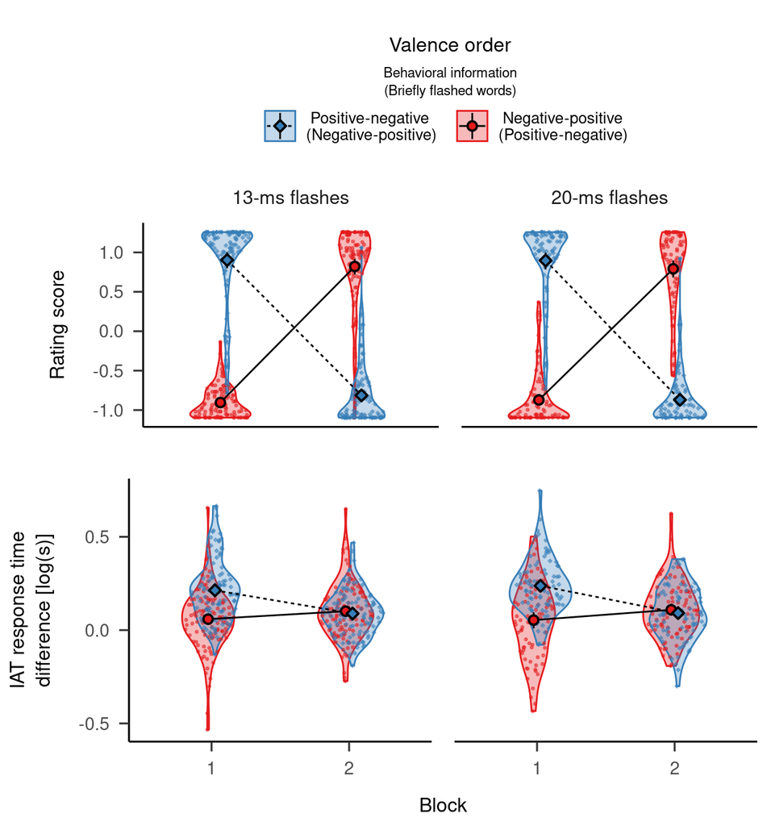

Figure 2.1: Black-rimmed points represent condition means, error bars represent 95% bootstrap confidence intervals based on 10,000 samples, small points represent individual participants’ responses, and violins represent kernel density estimates of sample distributions.

```r
plot_grid(
  otm2_rating_plot +
    theme(
      axis.title.x = element_blank()
      , axis.ticks.x = element_blank()
      , axis.text.x = element_blank()
      , axis.title.y = element_text(lineheight = 1.7)
      , strip.background = element_blank()
    )
  , NULL
  , otm2_iatscore_plot +
    theme(strip.text.x = element_blank())
  , ncol = 1
  , rel_heights = c(1, 0.05, 0.8)
)
```

Figure 2.2 shows the results across the 5 data collection sites. At the University of Florida and Williams College, the presentation duration was 13 ms, while at the other sites it was 20 ms. The results are highly consistent across sites, with the same pattern of results for explicit and implicit attitude measures.

```r
otm2_rating_plot2 <- otm2_attitudes %>%
  mutate(
    ValenceBlock = ifelse(
      ValenceBlock == "Positive-negative"
      , " Positive-negative\n(Negative-positive)"
      , " Negative-positive\n(Positive-negative)")
    , Duration = paste0(Duration, "-ms flashes")
  ) %>%
  ggplot(aes(x = Block, y = Eval, color = ValenceBlock, fill = ValenceBlock, shape = ValenceBlock)) +
  geom_violin(position = position_dodge(0.1), alpha = 0.3) +
  # geom_point(position = position_jitterdodge(jitter.width = 0.1, dodge.width = 0.1)) +
  geom_sina(position = position_dodge(0.1), alpha = 0.5, size = 0.5) +
  stat_summary(fun = mean, aes(group = ValenceBlock, linetype = ValenceBlock), geom = "line", position = position_dodge(0.1), color = "black") +
  stat_summary(fun.data = mean_cl_boot, position = position_dodge(0.1), color = "black", fun.args = list(B = 10000)) +
  scale_color_brewer(palette = "Set1", guide = otm2_results_legend) +
  scale_fill_brewer(palette = "Set1", guide = otm2_results_legend) +
  scale_shape_manual(values = c(21, 23), guide = otm2_results_legend) +
  labs(
    x = "Block"
    , y = " \nRating score"
  ) +
  guides(linetype = otm2_results_legend) +
  facet_wrap(~ Location, ncol = 3) +
  theme(
    legend.position = "top"
    , legend.justification = "center"
  )
```

```r
otm2_iatscore_plot2 <- otm2_attitudes %>%
  mutate(
    ValenceBlock = ifelse(
      ValenceBlock == "Positive-negative"
      , " Positive-negative\n(Negative-positive)"
      , " Negative-positive\n(Positive-negative)")
    , Duration = paste0(Duration, "-ms flashes")
  ) %>%
  ggplot(aes(x = Block, y = IATscore, color = ValenceBlock, fill = ValenceBlock, shape = ValenceBlock)) +
  geom_violin(position = position_dodge(0.1), alpha = 0.3) +
  # geom_point(position = position_jitterdodge(jitter.width = 0.1, dodge.width = 0.1)) +
  geom_sina(position = position_dodge(0.1), alpha = 0.5, size = 0.5) +
  stat_summary(fun = mean, aes(group = ValenceBlock, linetype = ValenceBlock), geom = "line", position = position_dodge(0.1), color = "black") +
  stat_summary(fun.data = mean_cl_boot, position = position_dodge(0.1), color = "black", fun.args = list(B = 10000)) +
  scale_color_brewer(palette = "Set1") +
  scale_fill_brewer(palette = "Set1") +
  scale_shape_manual(values = c(21, 23)) +
  labs(
    x = "Block"
    , y = "IAT response time\ndifference [log(s)]"
  ) +
  facet_wrap(~ Location, ncol = 3) +
  theme(legend.position = "none")
```

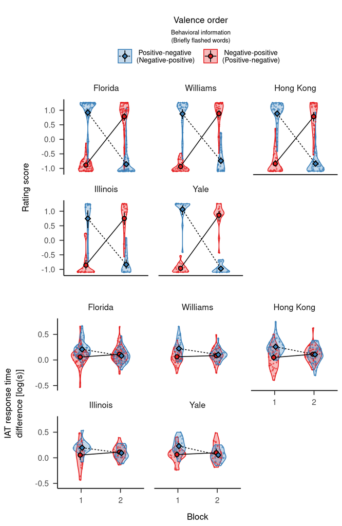

Figure 2.2: Black-rimmed points represent condition means, error bars represent 95% bootstrap confidence intervals based on 10,000 samples, small points represent individual participants’ responses, and violins represent kernel density estimates of sample distributions.

```r
plot_grid(
  otm2_rating_plot2 +
    theme(
      axis.title.x = element_blank()
      , axis.ticks.x = element_blank()
      , axis.text.x = element_blank()
      , axis.title.y = element_text(lineheight = 1.7)
      , strip.background = element_blank()
    )
  , NULL
  , otm2_iatscore_plot2
  , ncol = 1
  , rel_heights = c(1, 0.05, 0.8)
)
```

## 2.1 Frequentist analysis

The following are ANOVA tables present the results across both attitude measures and the two presentation durations or data collection sites. The ValenceBlock $\times$ Block interaction represents the cross-over interaction shown in Figures 2.1 and 2.2. The ValenceBlock $\times$ Block interaction $\times$ Measure interaction indicates when this interaction differed between measures, which the “Two minds” hypothesis predicts. However, note that the hypothesis predicts a specific interaction, namely a complete reversal of the cross-over interaction. The ValenceBlock $\times$ Block interaction $\times$ Measure $\times$ Duration interaction indicates if the presentation Duration affects this predicted outcome.

In broad strokes, we find the three-way interaction with no indication that it is affected by presentation duration. However, as Figures 2.1 clearly shows, the interaction is owed to the fact that the cross-over interaction is more pronounced for explicit attitude ratings than for IAT scores, but we see no reversal of the effects.

```r
otm2_attitudes_aov <- otm2_attitudes %>%
  mutate(
    Eval = scale(Eval) %>% as.numeric
    , IATscore = scale(IATscore) %>% as.numeric
  ) %>%
  gather("Measure", "Attitude", Eval, IATscore) %>%
  mutate(Measure = factor(Measure)) %>%
  aov_ez(
    id = "ParticipantNumber"
    , dv = "Attitude"
    , within = c("Block", "Measure")
    # , between = "ValenceBlock"
    , between = c("ValenceBlock", "Duration")
    , data = .
  )

otm2_attitudes_aov %>%
  apa_print %$%
  table %>%
  apa_table(
    caption = "Results of the combined ANOVA of \(z\) standardized attitude ratings and IAT scores."
    , escape = FALSE
  )
```

Table 2.1: Results of the combined ANOVA of $z$ standardized attitude ratings and IAT scores.

| Effect | $\hat{\eta}^2_G$ | $F$ | $\mathit{df}^{\mathrm{GG}}$ | $\mathit{df}_{\mathrm{res}}^{\mathrm{GG}}$ | $\mathit{MSE}$ | $p$ |
| --- | --- | --- | --- | --- | --- | --- |
| ValenceBlock | .032 | 35.70 | 1 | 382 | 0.75 | < .001 |
| Duration | .000 | 0.10 | 1 | 382 | 0.75 | .756 |
| Block | .009 | 18.10 | 1 | 382 | 0.42 | < .001 |
| Measure | .000 | 0.03 | 1 | 382 | 0.59 | .866 |
| ValenceBlock $\times$ Duration | .000 | 0.05 | 1 | 382 | 0.75 | .830 |
| ValenceBlock $\times$ Block | .388 | 1,237.27 | 1 | 382 | 0.42 | < .001 |
| Duration $\times$ Block | .000 | 0.41 | 1 | 382 | 0.42 | .520 |
| ValenceBlock $\times$ Measure | .017 | 23.89 | 1 | 382 | 0.59 | < .001 |
| Duration $\times$ Measure | .000 | 0.55 | 1 | 382 | 0.59 | .459 |
| Block $\times$ Measure | .006 | 13.77 | 1 | 382 | 0.37 | < .001 |
| ValenceBlock $\times$ Duration $\times$ Block | .000 | 0.53 | 1 | 382 | 0.42 | .469 |
| ValenceBlock $\times$ Duration $\times$ Measure | .000 | 0.45 | 1 | 382 | 0.59 | .503 |
| ValenceBlock $\times$ Block $\times$ Measure | .151 | 387.10 | 1 | 382 | 0.37 | < .001 |
| Duration $\times$ Block $\times$ Measure | .000 | 0.06 | 1 | 382 | 0.37 | .801 |
| ValenceBlock $\times$ Duration $\times$ Block $\times$ Measure | .000 | 0.75 | 1 | 382 | 0.37 | .388 |

```r
otm2_attitudes_country_aov <- otm2_attitudes %>%
  mutate(
    Eval = scale(Eval) %>% as.numeric
    , IATscore = scale(IATscore) %>% as.numeric
  ) %>%
  gather("Measure", "Attitude", Eval, IATscore) %>%
  mutate(Measure = factor(Measure)) %>%
  aov_ez(
    id = "ParticipantNumber"
    , dv = "Attitude"
    , within = c("Block", "Measure")
    # , between = "ValenceBlock"
    , between = c("ValenceBlock", "Location")
    , data = .
  )

otm2_attitudes_country_aov %>%
  apa_print %$%
  table %>%
  apa_table(
    caption = "Results of the combined ANOVA of \(z\) standardized attitude ratings and IAT scores."
    , escape = FALSE
  )
```

Table 2.2: Results of the combined ANOVA of $z$ standardized attitude ratings and IAT scores.

| Effect | $\hat{\eta}^2_G$ | $F$ | $\mathit{df}^{\mathrm{GG}}$ | $\mathit{df}_{\mathrm{res}}^{\mathrm{GG}}$ | $\mathit{MSE}$ | $p$ |
| --- | --- | --- | --- | --- | --- | --- |
| ValenceBlock | .025 | 27.03 | 1 | 376 | 0.76 | < .001 |
| Location | .001 | 0.33 | 4 | 376 | 0.76 | .859 |
| Block | .008 | 14.73 | 1 | 376 | 0.42 | < .001 |
| Measure | .000 | 0.00 | 1 | 376 | 0.60 | .977 |
| ValenceBlock $\times$ Location | .001 | 0.34 | 4 | 376 | 0.76 | .849 |
| ValenceBlock $\times$ Block | .343 | 1,009.58 | 1 | 376 | 0.42 | < .001 |
| Location $\times$ Block | .001 | 0.65 | 4 | 376 | 0.42 | .624 |
| ValenceBlock $\times$ Measure | .013 | 18.40 | 1 | 376 | 0.60 | < .001 |
| Location $\times$ Measure | .001 | 0.28 | 4 | 376 | 0.60 | .889 |
| Block $\times$ Measure | .006 | 12.17 | 1 | 376 | 0.38 | < .001 |
| ValenceBlock $\times$ Location $\times$ Block | .002 | 0.98 | 4 | 376 | 0.42 | .420 |
| ValenceBlock $\times$ Location $\times$ Measure | .002 | 0.51 | 4 | 376 | 0.60 | .727 |
| ValenceBlock $\times$ Block $\times$ Measure | .131 | 322.43 | 1 | 376 | 0.38 | < .001 |
| Location $\times$ Block $\times$ Measure | .001 | 0.58 | 4 | 376 | 0.38 | .678 |
| ValenceBlock $\times$ Location $\times$ Block $\times$ Measure | .001 | 0.64 | 4 | 376 | 0.38 | .632 |

```r
# # Split analyses by Location
# otm2_attitudes_country_split_aov <- otm2_attitudes_country_aov %>%
#   ref_grid %>%
#   joint_tests(by = "Location")# %>%
#   # filter(`model term` == "ValenceBlock:Measure:Block")

# otm2_attitudes_country_split_aov

otm2_attitudes_country_split_aov <- otm2_attitudes_country_aov %>%
  ref_grid(at = list(Location = c("Hong Kong", "Illinois", "Yale"))) %>%
  add_grouping("Culture", "Location", c("Hong Kong", "USA", "USA")) %>%
  emmeans(specs = ~ Block * Measure * ValenceBlock * Culture) |>
  joint_tests(by = "Culture")
```

### 2.1.1 Explicit attitudes

```r
otm2_explicit_aov <- aov_ez(
  id = "ParticipantNumber"
  , dv = "Eval"
  , within = "Block"
  # , between = "ValenceBlock"
  , between = c("ValenceBlock", "Duration")
  , data = otm2_attitudes
)

otm2_explicit_aov %>%
  apa_print %$%
  table %>%
  apa_table(
    caption = "ANOVA results for attitude ratings."
    , escape = FALSE
  )
```

Table 2.3: ANOVA results for attitude ratings.

| Effect | $\hat{\eta}^2_G$ | $F$ | $\mathit{df}^{\mathrm{GG}}$ | $\mathit{df}_{\mathrm{res}}^{\mathrm{GG}}$ | $\mathit{MSE}$ | $p$ |
| --- | --- | --- | --- | --- | --- | --- |
| ValenceBlock | .006 | 6.28 | 1 | 382 | 0.15 | .013 |
| Duration | .000 | 0.29 | 1 | 382 | 0.15 | .593 |
| Block | .001 | 0.47 | 1 | 382 | 0.23 | .493 |
| ValenceBlock $\times$ Duration | .000 | 0.34 | 1 | 382 | 0.15 | .557 |
| ValenceBlock $\times$ Block | .797 | 2,478.50 | 1 | 382 | 0.23 | < .001 |
| Duration $\times$ Block | .001 | 0.67 | 1 | 382 | 0.23 | .415 |
| ValenceBlock $\times$ Duration $\times$ Block | .000 | 0.01 | 1 | 382 | 0.23 | .932 |

```r
# Split analyses by Location
otm2_explicit_country_aov <- aov_ez(
  id = "ParticipantNumber"
  , dv = "Eval"
  , within = "Block"
  # , between = "ValenceBlock"
  , between = c("ValenceBlock", "Location")
  , data = otm2_attitudes
)

# otm2_explicit_country_split_aov <- otm2_explicit_country_aov %>%
#   ref_grid %>%
#   joint_tests(by = "Location")# %>%
#   # filter(`model term` == "ValenceBlock:Block")

# otm2_explicit_country_split_aov
```

```r
emmeans(otm2_explicit_aov, ~ Block | ValenceBlock) %>%
  contrast(
    method = list("Block 2 - Block 1" = c(-1, 1))
    , adjust = "none"
  ) %>%
  apa_print %$%
  table %>%
  select(-contrast) %>%
  rename("Valence order" = ValenceBlock) %>%
  apa_table(
    caption = "Planned contrasts (Block 2 - Block 1) for the ANOVA of attitude ratings."
    , escape = FALSE
    , row.names = FALSE
  )
```

Table 2.4: Planned contrasts (Block 2 - Block 1) for the ANOVA of attitude ratings.

| ValenceBlock | $\Delta M$ | 95% CI | $t$ | $\mathit{df}$ | $p$ |
| --- | --- | --- | --- | --- | --- |
| Negative-positive | 1.70 | [1.60, 1.79] | 34.95 | 382 | < .001 |
| Positive-negative | -1.74 | [-1.84, -1.65] | -35.45 | 382 | < .001 |

### 2.1.2 Implicit attitudes

```r
otm2_iat_aov <- aov_ez(
  id = "ParticipantNumber"
  , dv = "IATscore"
  , within = "Block"
  # , between = "ValenceBlock"
  , between = c("ValenceBlock", "Duration")
  , data = otm2_attitudes
)
otm2_iat_aov %>%
  apa_print %$%
  table %>%
  apa_table(
    caption = "ANOVA results for IAT scores."
    , escape = FALSE
  )
```

Table 2.5: ANOVA results for IAT scores.

| Effect | $\hat{\eta}^2_G$ | $F$ | $\mathit{df}^{\mathrm{GG}}$ | $\mathit{df}_{\mathrm{res}}^{\mathrm{GG}}$ | $\mathit{MSE}$ | $p$ |
| --- | --- | --- | --- | --- | --- | --- |
| ValenceBlock | .057 | 33.73 | 1 | 382 | 0.03 | < .001 |
| Duration | .001 | 0.30 | 1 | 382 | 0.03 | .585 |
| Block | .019 | 22.98 | 1 | 382 | 0.02 | < .001 |
| ValenceBlock $\times$ Duration | .000 | 0.21 | 1 | 382 | 0.03 | .649 |
| ValenceBlock $\times$ Block | .080 | 104.28 | 1 | 382 | 0.02 | < .001 |
| Duration $\times$ Block | .000 | 0.06 | 1 | 382 | 0.02 | .803 |
| ValenceBlock $\times$ Duration $\times$ Block | .001 | 0.91 | 1 | 382 | 0.02 | .342 |

```r
# Split analyses by Location
otm2_iat_country_aov <- aov_ez(
  id = "ParticipantNumber"
  , dv = "IATscore"
  , within = "Block"
  # , between = "ValenceBlock"
  , between = c("ValenceBlock", "Location")
  , data = otm2_attitudes
)

# otm2_iat_country_split_aov <- otm2_iat_country_aov %>%
#   ref_grid %>%
#   joint_tests(by = "Location")# %>%
#   # filter(`model term` == "ValenceBlock:Block")

# otm2_iat_country_split_aov
```

```r
emmeans(otm2_iat_aov, ~ Block | ValenceBlock) %>%
  contrast(
    method = list("Block 2 - Block 1" = c(-1, 1))
    , adjust = "none"
  ) %>%
  apa_print %$%
  table %>%
  select(-contrast) %>%
  rename("Valence order" = ValenceBlock) %>%
  apa_table(
    caption = "Planned contrasts (Block 2 - Block 1) for the ANOVA of IAT scores."
    , escape = FALSE
    , row.names = FALSE
  )
```

Table 2.6: Planned contrasts (Block 2 - Block 1) for the ANOVA of IAT scores.

| ValenceBlock | $\Delta M$ | 95% CI | $t$ | $\mathit{df}$ | $p$ |
| --- | --- | --- | --- | --- | --- |
| Negative-positive | 0.05 | [0.02, 0.07] | 3.86 | 382 | < .001 |
| Positive-negative | -0.14 | [-0.16, -0.11] | -10.54 | 382 | < .001 |

### 2.1.3 Differences between implicit and explicit attitudes

As in the original study, we compared participants’ $z$ standardized attitude toward Bob assessed by ratings and IAT scores.

```r
otm2_attitudes_aov %>%
    emmeans(~ Measure | ValenceBlock * Block * Duration) %>%
    pairs() |>
    apa_print() %$%
    table %>%
    select(-contrast) %>%
    rename("Valence order" = ValenceBlock) %>%
    apa_table(
      caption = "Results of follow-up analysis comparing differences between attitude ratings and IAT scores in all experimental conditions."
      , escape = FALSE
      , row.names = FALSE
    )
```

Table 2.7: Results of follow-up analysis comparing differences between attitude ratings and IAT scores in all experimental conditions.

| Duration | Block | ValenceBlock | $\Delta M$ | 95% CI | $t$ | $\mathit{df}$ | $p$ |
| --- | --- | --- | --- | --- | --- | --- | --- |
| 13 | X1 | Negative-positive | -0.58 | [-0.78, -0.38] | -5.71 | 382 | < .001 |
|  |  | Positive-negative | 0.38 | [0.17, 0.58] | 3.62 | 382 | < .001 |
|  | X2 | Negative-positive | 0.96 | [0.80, 1.12] | 11.55 | 382 | < .001 |
|  |  | Positive-negative | -0.67 | [-0.83, -0.50] | -7.83 | 382 | < .001 |
| 20 | X1 | Negative-positive | -0.52 | [-0.75, -0.29] | -4.39 | 382 | < .001 |
|  |  | Positive-negative | 0.23 | [-0.01, 0.46] | 1.92 | 382 | .056 |
|  | X2 | Negative-positive | 0.88 | [0.70, 1.07] | 9.21 | 382 | < .001 |
|  |  | Positive-negative | -0.74 | [-0.93, -0.55] | -7.65 | 382 | < .001 |

### 2.1.4 Recognition task

Finally, we tested participants recognition memory for the primes presented during the learning procedure.

Figure 2.3 clearly shows that our procdure resulted in at-chance prime recognition accuracy when the primes were presented for 13 ms, but slightly above chance performance when they were presented for 20 ms.

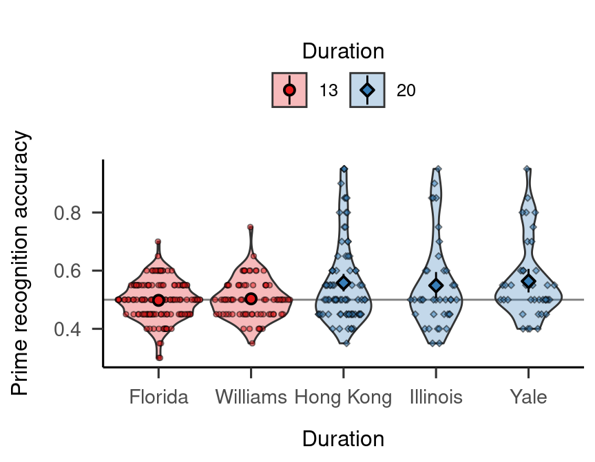

Figure 2.3: Black-rimmed points represent condition means, error bars represent 95% bootstrap confidence intervals based on 10,000 samples, small points represent individual participants’ responses, and violins represent kernel density estimates of sample distributions.

```r
otm2_results_legend2 <- guide_legend(
    title.position = "top"
    , title.hjust = 0.5
  )

otm2_mem %>%
  ggplot(aes(x = Location, y = Accuracy, shape = Duration, fill = Duration)) +
  geom_hline(yintercept = 0.5, color = grey(0.5)) +
  geom_violin(alpha = 0.3) +
  # geom_point(position = position_jitterdodge(jitter.width = 0.1, dodge.width = 0.1)) +
  geom_sina(alpha = 0.5, size = 1) +
  # stat_summary(fun = mean, aes(group = Location, linetype = ValenceBlock), geom = "line", position = position_dodge(0.1), color = "black") +
  stat_summary(fun.data = mean_cl_boot, color = "black", fun.args = list(B = 10000)) +
  # scale_color_brewer(palette = "Set1", guide = otm2_results_legend) +
  # scale_fill_brewer(palette = "Set1", guide = otm2_results_legend) +
  scale_shape_manual(values = c(21, 23, 24)) +
  scale_color_manual(values = c(RColorBrewer::brewer.pal(3, "Set1"), "#000000")) +
  scale_fill_manual(values = c(RColorBrewer::brewer.pal(3, "Set1"), "#000000")) +
  guides(shape = otm2_results_legend2) +
  labs(
    x = "Duration"
    , y = "Prime recognition accuracy"
  ) +
  theme(
    legend.position = "top"
    , legend.justification = "center"
  )
```

Table 2.8 show that the 20 ms presentation duration yieled high prime recognition accuracy, than 13 ms presentation duration. We found no indication of any additional heterogeneity across data collection sites.

```r
otm2_mom_aov <- aov(Accuracy ~ Duration + Location, data = otm2_mem %>%
  droplevels)

otm2_mom_aov |>
  apa_print() %$%
  table %>%
  apa_table(
    escape = FALSE
    , caption = "ANOVA results of prime recognition accuracy."
  )
```

Table 2.8: ANOVA results of prime recognition accuracy.

| Effect | $\hat{\eta}^2_G$ | $F$ | $\mathit{df}$ | $\mathit{df}_{\mathrm{res}}$ | $\mathit{MSE}$ | $p$ |
| --- | --- | --- | --- | --- | --- | --- |
| Duration | .068 | 27.92 | 1 | 381 | 0.01 | < .001 |
| Location | .001 | 0.18 | 3 | 381 | 0.01 | .907 |

```r
otm2_mem_emm <- otm2_mom_aov %>%
  emmeans(~ Duration, nesting = "Location %in% Duration")
```

Follow-up NHST and non-superiority tests confirm above-chance recognition accuracy for words flashed for 20 ms and at-chance recognition accuracy for words flashed for 13 ms (with a non-superiority threshold of $\theta = 0.55$).

```r
otm2_mem_emm %>%
  summary(infer = TRUE, side = ">", null = 0.5, adjust = "bonferroni") |>
  apa_print() %$%
  table %>%
  apa_table(
    escape = FALSE
    , caption = "Follow-up tests of above-chance recognition accuracy for each duration of briefly flashed words. Test were Bonferroni-corrected for 2 comparisons."
  )
```

Table 2.9: Follow-up tests of above-chance recognition accuracy for each duration of briefly flashed words. Test were Bonferroni-corrected for 2 comparisons.

| Duration | Duration | $\hat{\theta}$ | $95\%\ \mathrm{CI}_\mathrm{\scriptstyle Bonferroni(2)}$ | $t$ | $\mathit{df}$ | $p_\mathrm{\scriptstyle Bonferroni(2)}$ |
| --- | --- | --- | --- | --- | --- | --- |
| 13 | 13 | 0.50 | [0.49, $\infty$]${}^a$ | 0.07 | 381 | .948${}^a$ |
| 20 | 20 | 0.56 | [0.54, $\infty$]${}^b$ | 6.56 | 381 | < .001${}^b$ |

```r
otm2_mem_emm %>%
  summary(infer = TRUE, side = "<", delta = 0.55, adjust = "bonferroni") |>
  apa_print() %$%
  table %>%
  apa_table(
    escape = FALSE
    , caption = "Follow-up non-superiority tests of above-chance recognition accuracy for each duration of briefly flashed words. Test were Bonferroni-corrected for 2 comparisons."
  )
```

Table 2.10: Follow-up non-superiority tests of above-chance recognition accuracy for each duration of briefly flashed words. Test were Bonferroni-corrected for 2 comparisons.

| Duration | Duration | $\hat{\theta}$ | $95\%\ \mathrm{CI}_\mathrm{\scriptstyle Bonferroni(2)}$ | $t$ | $\mathit{df}$ | $p_\mathrm{\scriptstyle Bonferroni(2)}$ |
| --- | --- | --- | --- | --- | --- | --- |
| 13 | 13 | 0.50 | [-$\infty$, 0.52]${}^a$ | -6.67 | 381 | < .001${}^a$ |
| 20 | 20 | 0.56 | [-$\infty$, 0.57]${}^b$ | 0.80 | 381 | > .999${}^b$ |

## 2.2 Bayesian analysis

The following analyses are targeted hypothesis tests that compare models that instantiate the patterns of mean differences observed by Rydell et al. (2006) and Heycke et al. (2018). For simplicity we collapsed data across valence orders by reversing the coding of the blocks when Bob was first presented with negative and subsequently with positive descriptions. Hence, in the following analysis the first block represents responses following trials in which Bob was presented with positive descriptions. For both attitude measures we contrasted the first with the second block, such that positive values represent a more favorable attitude after the block in which Bob was presented with positive descriptions.

The first model of interest posits that the experimental manipulation has the same effect on attitude ratings and IAT scores, that is the direction of the effect is the same for both measures ($\mathcal{H}_\textrm{same direction}$; see Heycke et al., 2018). The competing model of interest predicts effects in opposite directions ($\mathcal{H}_\textrm{opposite directions}$; see Rydell et al., 2006). The following analysis assesses which of the two patterns is a better a priori-description of our findings.

We considered two additional control models: one model assumes no effect of the manipulation ($\mathcal{H}_\textrm{no effect}$), the other model is unconstrained and is compatible with any outcome ($\mathcal{H}_\textrm{unconstrained effect}$). If the latter model provides the best a priori-description of the data, the results are inconsistent with both previously reported outcomes.

We implemented the unconstrained model as a hierarchical linear model that encompasses each of the other models as special cases:

$$\begin{aligned}
\hat y_{ijk} = & \mu + \nu_i + \eta x_{1i} + \\
& (\alpha + \epsilon_i + \tau x_{1i}) x_{2j} x_{3k} + \\
& (\beta + \zeta_i + \upsilon x_{1i}) (1 - x_{2j}) x_{3k}
\end{aligned}$$

The model predicts the $i$th participant’s response to measure $j$ in the experimental block $k$. Responses are predicted as a combination of a grand mean $\mu$, random participant intercepts $\nu_i$ (i.e., habitually higher or lower attitudes), a main effect of the presentation duration $\eta$, and simple effects of experimental block for attitude ratings ($\alpha$) and IAT score ($\beta$). Additionally, we allowed the simple effects to be moderated by the presentation duration ($\tau$ and $\upsilon$ represent the lab-specific deviations from the overall simple effects). The model does not include a main effect of attitude measure because any mean differences between attitude measures were leveled by the $z$ standardization. $x_{1i}$ represents effect coded variables that indicate which presentation duration participant $i$ belongs to; $x_{2j}$ indicates the attitude measure (1 for explicit attitude rating and 0 for IAT score), such that $\alpha + \tau$ is only relevant for attitude ratings and $\beta + \upsilon$ is only relevant for IAT scores; $x_{3k}$ is an effect coded variable that is set to 0.5 for block 1 and -0.5 for block 2.

This model allowed us to place priors on the simple effects (in units of $d$) for each attitude measure and implement the theoretically motivated order constraints:

$$\begin{aligned}
\mathcal{H}_\textrm{no effect}:~ & \delta_\alpha = 0 \\ & \delta_\beta = 0 \\
\mathcal{H}_\textrm{same direction}:~ & \delta_\alpha \sim \textrm{Positive-Half-Cauchy}(r = \sqrt2/2) \\ & \delta_\beta \sim \textrm{Positive-Half-Cauchy}(r = \sqrt2/2) \\
\mathcal{H}_\textrm{opposite directions}:~ & \delta_\alpha \sim \textrm{Positive-Half-Cauchy}(r = \sqrt2/2) \\ & \delta_\beta \sim \textrm{Negative-Half-Cauchy}(r = \sqrt2/2) \\
\mathcal{H}_\textrm{unconstrained effect}:~ & \delta_\alpha \sim \textrm{Cauchy}(r = \sqrt2/2) \\ & \delta_\beta \sim \textrm{Cauchy}(r = \sqrt2/2)
\end{aligned}$$

Additionally, placed default multivariate Cauchy priors ($r = \sqrt2/2$) on presentation duration main effects $\eta$ and presentation duration effects on attitude differences between blocks for attitude ratings ($\tau$) and IAT score ($\upsilon$).

```r
tar_load(otm2_no_effect)
tar_load(otm2_unconstrained)
tar_load(otm2_no_duration_effect)

otm2_unconstrained_bf <- exp(otm2_unconstrained$bf - otm2_no_effect$bf)

# otm2_unconstrained_bf_res <- apa_print_bf(
#   otm2_unconstrained_bf
#   , ratio_subscript = "\\mathcal{H}_\\textrm{unconstrained effect}/\\mathcal{H}_\\textrm{no effect}"
# )

# No presentation duration effect model
otm2_no_duration_effect_bf <- exp(otm2_no_duration_effect$bf - otm2_no_effect$bf)

# otm2_no_duration_effect_bf_res <- apa_print_bf(
#   otm2_no_duration_effect_bf
#   , ratio_subscript = "\\mathcal{H}_\\textrm{no lab effects}/\\mathcal{H}_\\textrm{no effect}"
# )
```

```r
otm2_unconstrained_samples <- tar_read(otm2_unconstrained_samples_poi)
```

```r
# Fixed effect model
otm2_same_direction_boost <- 4 * (
  (sum(
    otm2_unconstrained_samples[, "alpha"] < 0 &
    otm2_unconstrained_samples[, "beta"] < 0
  ) + 1) / (nrow(otm2_unconstrained_samples) + 1)
)
otm2_same_direction_bf <- otm2_unconstrained_bf * otm2_same_direction_boost

otm2_same_direction_bf_res <- apa_print_bf(
  otm2_same_direction_bf
  , ratio_subscript = "\\mathcal{H}_\\textrm{same direction}/\\mathcal{H}_\\textrm{no effect}"
)

## Same direction in all labs
otm2_all_durations_same_direction_boost <- 8 * (
  (sum(
    otm2_unconstrained_samples[, "alpha_13"] < 0 &
    otm2_unconstrained_samples[, "beta_13"] < 0 &
    otm2_unconstrained_samples[, "alpha_20"] < 0 &
    otm2_unconstrained_samples[, "beta_20"] < 0
  ) + 1) / (nrow(otm2_unconstrained_samples) + 1)
)
otm2_all_durations_same_direction_bf <- otm2_unconstrained_bf * otm2_all_durations_same_direction_boost

# otm2_all_durations_same_direction_bf_res <- apa_print_bf(
#   otm2_all_durations_same_direction_bf
#   , ratio_subscript = "\\mathcal{H}_\\textrm{same direction}/\\mathcal{H}_\\textrm{no effect}"
# )
```

```r
# Fixed effect model
otm2_opposite_direction_boost <- 4 * (
  (sum(
    otm2_unconstrained_samples[, "alpha"] < 0 &
    otm2_unconstrained_samples[, "beta"] > 0
  ) + 1) / (nrow(otm2_unconstrained_samples) + 1)
)
otm2_opposite_direction_bf <- otm2_unconstrained_bf * otm2_opposite_direction_boost

# otm2_opposite_direction_bf_res <- apa_print_bf(
#   otm2_opposite_direction_bf
#   , ratio_subscript = "\\mathcal{H}_\\textrm{opposite direction}/\\mathcal{H}_\\textrm{no effect}"
#   , auto_invert = FALSE
# )

## Opposite direction in all locations
otm2_all_durations_opposite_direction_boost <- 8 * (
  (sum(
    otm2_unconstrained_samples[, "alpha_13"] < 0 &
    otm2_unconstrained_samples[, "beta_13"] > 0 &
    otm2_unconstrained_samples[, "alpha_20"] < 0 &
    otm2_unconstrained_samples[, "beta_20"] > 0
  ) + 1) / (nrow(otm2_unconstrained_samples) + 1)
)
otm2_all_durations_opposite_direction_bf <- otm2_unconstrained_bf * otm2_all_durations_opposite_direction_boost

# otm2_all_durations_opposite_direction_bf_res <- apa_print_bf(
#   otm2_all_opposite_direction_bf
#   , ratio_subscript = "\\mathcal{H}_\\textrm{opposite direction}/\\mathcal{H}_\\textrm{no effect}"
# )
```

```r
otm2_same_vs_opposite_direction_bf_res <- apa_print_bf(
  otm2_same_direction_bf / otm2_opposite_direction_bf
  , ratio_subscript = "\\mathcal{H}_\\textrm{same direction}/\\mathcal{H}_\\textrm{opposite direction}"
)

otm2_same_direction_vs_unconstrained_bf_res <- apa_print_bf(
  otm2_same_direction_bf / otm2_unconstrained_bf
  , ratio_subscript = "\\mathcal{H}_\\textrm{same direction}/\\mathcal{H}_\\textrm{unconstrained effect}"
)

# In all durations
otm2_all_durations_same_direction_vs_unconstrained_bf_res <- apa_print_bf(
  otm2_all_durations_same_direction_bf / otm2_unconstrained_bf
  , ratio_subscript = "\\mathcal{H}_\\textrm{all same direction}/\\mathcal{H}_\\textrm{unconstrained effect}"
)

otm2_all_durations_same_vs_same_direction_bf_res <- apa_print_bf(
  otm2_all_durations_same_direction_bf / otm2_same_direction_bf
  , ratio_subscript = "\\mathcal{H}_\\textrm{all same direction}/\\mathcal{H}_\\textrm{same effect}"
)

otm2_no_duration_effect_bf_res <- apa_print_bf(
  otm2_no_duration_effect_bf / otm2_unconstrained_bf
  , ratio_subscript = "\\mathcal{H}_\\textrm{no lab effect}/\\mathcal{H}_\\textrm{unconstrained effect}"
)
```

```r
otm2_attitudes_delta <- otm2_attitudes_collapsed %>%
  spread(Block, Attitude) %>%
  mutate(delta = `1` - `2`) %>%
  select(-`1`, -`2`)

otm2_attitudes_delta_summary <- otm2_attitudes_delta %>%
  group_by(Measure) %>%
  summarize(delta = mean(delta)) %>%
  ungroup %>%
  spread(Measure, delta)

otm2_attitudes_delta_summary <- otm2_attitudes_delta %>%
  group_by(Measure, Duration) %>%
  summarize(delta = mean(delta)) %>%
  ungroup %>%
  spread(Measure, delta) %>%
  rbind(cbind(Duration = "Overall", otm2_attitudes_delta_summary))
```

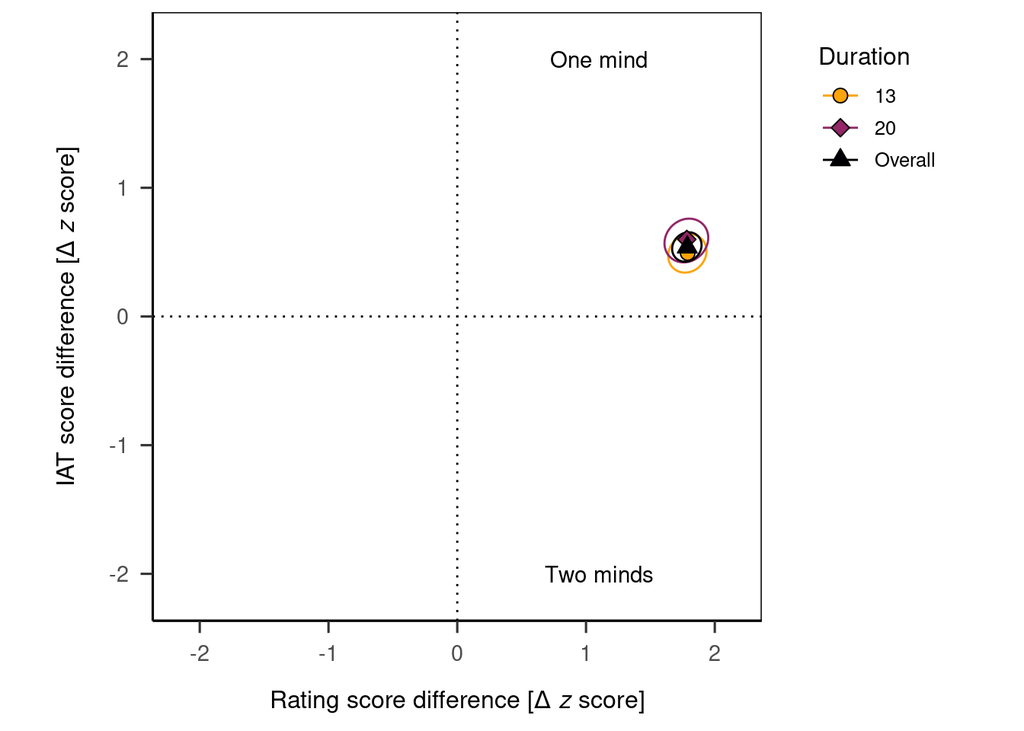

```r
tar_load(otm2_unconstrained_pp)

otm2_attitudes_delta_summary %>%
  ggplot(aes(x = Eval, y = IATscore, color = Duration, fill = Duration, shape = Duration)) +
  geom_hline(yintercept = 0, linetype = "dotted") +
  geom_vline(xintercept = 0, linetype = "dotted") +
  # stat_density_2d(
  #   data = otm2_unconstrained_effect_fixed_pp
  #   , aes(x = alpha, y = beta, color = Duration)
  #   , bins = 5
  #   , inherit.aes = FALSE
  # ) +
  stat_ellipse(
    data = otm2_unconstrained_pp
    , type = "norm"
    , level = 0.95
  ) +
  # stat_hpd_2d(
  #   data = otm2_unconstrained_pp
  #   , prob = 0.95
  #   , alpha = 0.1
  # ) +
  geom_point(size = 3, color = "black") +
  # geom_point(
  #   data = otm2_unconstrained_effect_fixed_pp %>%
  #     summarize(alpha = median(alpha), beta = median(beta))
  #   , aes(x = alpha, y = beta)
  #   , color = "black"
  #   , inherit.aes = FALSE
  # ) +
  annotate(geom = "text", x = 1.1, y = 2, label = "One~mind", parse = TRUE, hjust = 0.5) +
  annotate(geom = "text", x = 1.1, y = -2, label = "Two~minds", parse = TRUE, hjust = 0.5) +
  scale_color_viridis_d(option = "B", direction = -1, end = 0.8) +
  scale_fill_viridis_d(option = "B", direction = -1, end = 0.8) +
  scale_shape_manual(values = c(21, 23, 24)) +
  labs(
    x = expression(paste("Rating score difference [", Delta~italic(z)~score, "]"))
    , y = expression(paste("IAT score difference [", Delta~italic(z)~score, "]"))
  ) +
  coord_fixed(xlim = c(-2.15, 2.15), ylim = c(-2.15, 2.15)) +
  theme_apa(box = TRUE) +
  theme(
    legend.justification = c(0, 1)
    , legend.position.inside = c(-0.01, 1.03)
    , legend.background = element_blank()
    , legend.key.height = unit(1.1, "line")
    , legend.key.width = unit(1.5, "line")
  )
```

The direct comparison of the prior predictive accuracy of the previously reported result patterns indicated that our data were overall most consistent with the results reported by Heycke et al. (2018), $\mathrm{BF}_{\textrm{\mathcal{H}_\textrm{same direction}/\mathcal{H}_\textrm{opposite direction}}} = 1.00 \times 10^{6}$ (the Bayes factor is estimated as infinitely large due to numerical imprecision of the MCMC sampling approach). Additional comparisons with the control models confirmed that our experimental manipulations were effective ($\mathrm{BF}_{\textrm{\mathcal{H}_\textrm{same direction}/\mathcal{H}_\textrm{no effect}}} = 2.67 \times 10^{177}$) and did not produce an unexpected result pattern ($\mathrm{BF}_{\textrm{\mathcal{H}_\textrm{same direction}/\mathcal{H}_\textrm{unconstrained effect}}} = 4.00$, range $[0, 4]$[^1]).

To formally assess whether the data from all labs homogeneously exhibited effects in the same direction we added another model that enforced the order constrained of the $\mathcal{M}_\textrm{same direction}$ not only on the average block effects ($\alpha$ and $\beta$) but on each labs block effect ($\alpha + \tau_l$ and $\beta + \upsilon_l$, $\mathcal{H}_\textrm{all same direction}$). The data provide evidence in favor of homogeneous result patterns in all labs, $\mathrm{BF}_{\textrm{\mathcal{H}_\textrm{all same direction}/\mathcal{H}_\textrm{same effect}}} = 2.00$ (range $[0, 2]$) and $\mathrm{BF}_{\textrm{\mathcal{H}_\textrm{all same direction}/\mathcal{H}_\textrm{unconstrained effect}}} = 8.00$ (range $[0, 8]$[^2]).

### 2.2.1 Recognition task

First, we tested whether participants’ recognition accuracy for primes presented during the learning procedure differed between presentation durations using a Bayesian ANOVA with default a Cauchy prior ($r = \sqrt2/2$). We then tested whether recognition accuracy was above chance for each presentation duration separately using one-tailed Bayesian $t$ test with a default Cauchy prior ($r = \sqrt2/2$).

```r
otm2_mem_accuracy_duration_res <- otm2_mem %>%
  anovaBF(
    Accuracy ~ Duration
    , data = .
  ) %>%
  apa_print %$%
  statistic

otm2_mem_accuracy_13_res <- otm2_mem %>%
  filter(Duration == "13") %>%
  pull(Accuracy) %>%
  { ttestBF(x = ., mu = 0.5, nullInterval = c(0, Inf))[1] } %>%
  apa_print %$%
  full_result

otm2_mem_accuracy_20_res <- otm2_mem %>%
  filter(Duration == "20") %>%
  pull(Accuracy) %>%
  { ttestBF(x = ., mu = 0.5, nullInterval = c(0, Inf))[1] } %>%
  apa_print %$%
  full_result

otm2_mem_accuracy_hetero_res <- otm2_mem %>%
  {
    lmBF(Accuracy ~ Location, data = .) /
    lmBF(Accuracy ~ Duration , data = .)
  } %>%
  apa_print %$%
  statistic
```

The data strongly support the conclusion that participants’ recognition accuracy was better when primes were presented for 20 ms than for 13 ms, $\mathrm{BF}_{\textrm{10}} = 58,551.98$. In the 13 ms condition we found strong evidence against above-chance recognition accuracy , $M = 0.50$, 95% HDI $[0.49, 0.51]$, $\mathrm{BF}_{\textrm{10}} = 7.26 \times 10^{-2}$, whereas in the 20 ms condition we found strong evidence in favor of above-chance recognition accuracy, $M = 0.56$, 95% HDI $[0.53, 0.58]$, $\mathrm{BF}_{\textrm{10}} = 47,554.39$. In an additional analysis we tested whether there was heterogeneity in recognition accuracy between data collection sites beyond differences due to presentation duration. We found strong evidence against heterogenity, $\mathrm{BF}_{\textrm{10}} = 2.02 \times 10^{-2}$.

## 2.3 Prime recogniton and implicit attitudes

We performed an additional exploratory errors-in-variable regression analysis of prime recognition and the IAT score difference between blocks where positive values represent a more favorable attitude after the block in which Bob was presented with positive explicit descriptions. A negative value of the IAT score difference between blocks would therefore indicate that the IAT effects were in line with the prime valence. If prime recognition indeed obstructed the formation of associations, we would expect to observe a positive relationship between prime recognition accuracy and IAT score differences between blocks: When prime recognition is high we would expect IAT differences in line with the valence of the explicit descriptions of Bob but not with the prime valence; we would expect to observe smaller and eventually negative IAT differences as prime recognition memory declines and associative learning takes over. However, as in Experiment 1, we find no indication that this is the case.

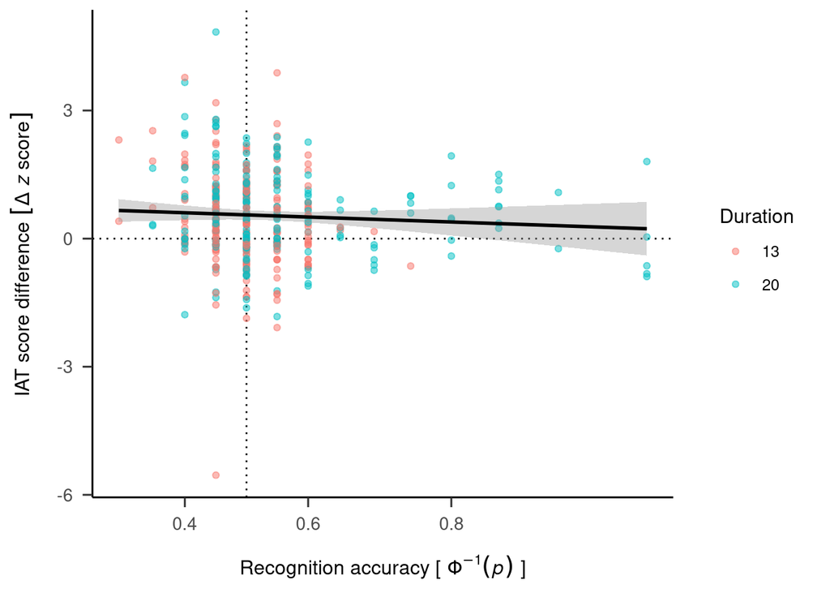

Figure 2.5: Scatterplot of prime recognition accuracy and attitude differences in IAT scores between blocks in which Bob was presented with positive descriptions and those in which he was paired with negative descriptions.

```r
otm2_iat_delta <- full_join(otm2_attitudes_delta, select(otm2_mem, ParticipantNumber, Accuracy), by = join_by(ParticipantNumber)) %>%
  filter(Measure == "IATscore")

otm2_iat_delta %>%
  ggplot(aes(x = Accuracy, y = delta, color = Duration)) +
  geom_hline(yintercept = 0, linetype = "dotted") +
  geom_vline(xintercept = 0.5, linetype = "dotted") +
  geom_point(alpha = 0.5) +
  geom_smooth(method = "eiv_lm", color = "black", method.args = list(n.optim = 50)) +
  # geom_smooth(method = "lm") +
  labs(
    x = bquote("Recognition accuracy ["~Phi^-1*(italic(p))~"]")
    , y = expression("IAT score difference"~group("[", Delta~italic(z)~score, "]"))
  ) +
  scale_x_continuous(trans = "probit")
```

```r
otm2_recognition_iat_lm_bf <- otm2_iat_delta %>%
  filter(Measure == "IATscore") %>%
  mutate(Accuracy = Accuracy - 0.5) %>%
  as.data.frame %>%
  generalTestBF(delta ~ Accuracy, data = ., whichModels = "top") %>%
  apa_print

# otm2_iat_delta %>%
#   filter(Measure == "IATscore") %>%
#   mutate(Accuracy = Accuracy - 0.5) %>%
#   lm(delta ~ Accuracy * Duration, data = .) %>%
#   apa_print %$%
#   table %>%
#   apa_table(
#     caption = "Results of linear error-in-variables regression predicting attitude differences in IAT scores between blocks with prime recognition accuracy."
#     , escape = FALSE
#   )

otm2_iat_delta %>%
  filter(Measure == "IATscore") %>%
  mutate(Accuracy = qnorm(Accuracy)) %>%
  eiv_lm(delta ~ Accuracy, data = ., n.optim = 50)  |>
  apa_print() %$%
  table %>%
  apa_table(
    escape = FALSE
    , caption = "Results of linear error-in-variables regression predicting attitude differences in IAT scores between blocks with prime recognition accuracy."
  )
```

Table 2.11: Results of linear error-in-variables regression predicting attitude differences in IAT scores between blocks with prime recognition accuracy.

| Predictor | $b$ | 95% CI | $z$ | $p$ |
| --- | --- | --- | --- | --- |
| Intercept | 0.56 | 95% CI [0.44, 0.67] | 9.69 | < .001 |
| Accuracy | -0.20 | 95% CI [-0.59, 0.20] | -0.97 | .330 |

We were unable to detect a relationship between prime recognition and IAT score differences between blocks. Moreover, we centered prime recognition at 0.5 and found that the intercept of the regression line was greater than zero, which indicates a positive IAT score difference despite at-chance prime recognition. Hence, even for participants who exhibited no memory for prime attitudes assessed with the IAT were in line with the explicit descriptions of Bob. These results provide no indication that the deviation of our findings from those reported by Rydell et al. (2006) are attributable to the above-chance prime recognition accuracy in this study.